# Math 250 midterm 1 2025 AU

This is a an open-resource exam. You are free to discuss the problems with one another and to use sources such as books, videos, and the internet. However, your solutions must be your own; you may **not** directly request answers from people outside the class, including in online forums like StackOverflow. I monitor several such sites and will report violations of this policy to the academic honesty committee.

Be aware that code generated by LLMs like ChatGPT often does not meet the standards used in class and so may receive poor marks. All writing must be human-controlled and curated, even if a text generator is used in places. Copy/pasting paragraphs from GPT is a great way to get a C-.

As a general rule, you should include both code and neat output for all problems to generate a clear and attractive output file. All work should be done according to the best practices established in class. Functional code isn’t enough! Your work will also be graded for clarity and style.

Submit a single neat .html file to Moodle by Monday, October 6, at 10:00 am. **When you upload this file, you confirm that you understand all included code and can explain your process to me if asked.**

The first 6 problems refer to the `coffee` data set, available on Moodle. This set was featured in the July 7, 2020 edition of the Tidy Tuesday Challenge, linked [here](https://github.com/rfordatascience/tidytuesday/tree/main/data/2020/2020-07-07).

## Problem 1

Write a short paragraph (approx 3-5 sentences) with background information on this data set. Who collected it and how did it come to be in its present form? What can you tell me that isn’t obvious from a quick glance at the Tidy Tuesday Github? You should NOT need to include any code for this part.

## Problem 2

This data set includes one very obvious outlier in the `flavor` variable. Identify this observation, remove it from the set, then create an attractive plot showing the distribution of `flavor` ratings in this set. Why was removing the outlier a good idea here?

Save the resulting data frame as `coffee2` and use it for all future problems.

## Problem 3

Obtain a smaller data set that includes only the variables `farm_name`, `country_of_origin`, `color`, `flavor`, and all those with the word “number” in their name. Remove observations with fewer than 300 bags tested and keep only those are *not* green in color. Order the results by highest flavor rating. If there are ties, order these reverse-alphabetically. Glimpse your results.

## Problem 4

Recreate the following plot as closely as possible.

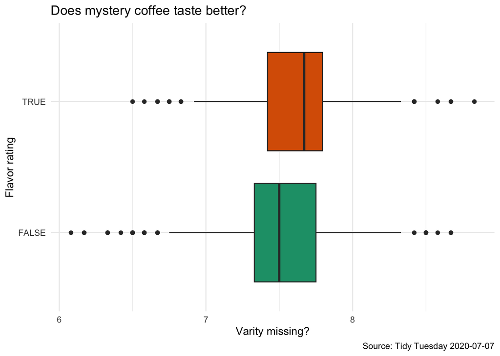

## Problem 5

Obtain a table showing the five most common countries of origin in `coffee2`. Include their average flavor ratings as well as their frequencies. Add a reasonable title to your table (you’ll need to learn how to do this).

## Problem 6

Obtain an attractive and informative plot showing the popularity of the various processing methods used in the countries identified in the last problem. Are there any apparent difference between nations here?

Note: you do not need to deeply research the missing values in the `processing_method` variable, but you should make an intelligent choice about how to treat them in your plot. Write a very short explanation of your choice.

## Problem 7

This problem deals with the `gss` data set, available on Moodle, which includes partial information from the [General Social Survey](https://gss.norc.org/), 2000-2014. Use this data to recreate the following plots as closely as possible.

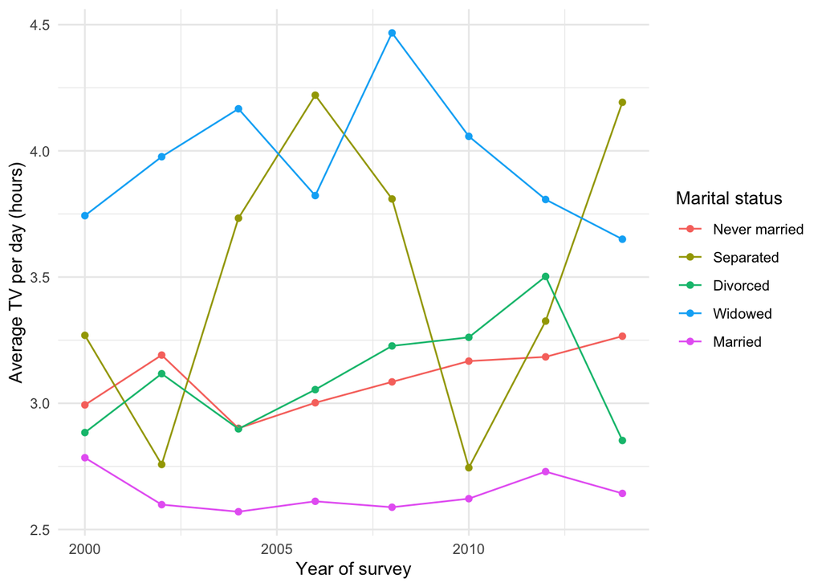